# Project Introduction

### Goal:

Discover the profile of high-value customers for a client's 3 product line segments: sweettreats, flavorfirst and modernhealth.

### Method:

Create a scikit-learn model to predict 3 segments' spendings over customers' other available information using a Tweedie regression model.

### Data:

Individual level data of demographic and purchase info aggregated over one year period:

- demographic information of the purchaser,
- total spending, units, and counts (number of months when any purchase was made) of any item (not limited to the 3 segments) over a year.
- spending, units and counts (number of months when any purchase was made) within the 3 segments over a year.

```python
#import packages
import pandas as pd
from patsy import dmatrices
import numpy as np
import statsmodels.api as sm
import matplotlib.pyplot as plt
from functools import partial
```

```python
#check sklearn version
import sklearn
sklearn.__version__
```

```
'0.23.1'
```

# Step1: Data Exploration

```python
#load data
df = pd.read_csv('df_common_hh_agg_complete_clean.csv', index_col='hhid')
```

```python
#check data type
df.dtypes.unique()
```

```
array([dtype('int64'), dtype('O'), dtype('float64')], dtype=object)
```

```python
df.head()
```

| hhid | designated_market_area_rank | local_county_size_code | residence_in_metro_county_flag | prizm_segment_nickname | psycle_segment_nickname | connexions_segment_nickname | spectra_reportable_classification_code | residence_ownership_status_desc | residence_structure_type_code | owns_secondary_residence_flag | ... | total_count | sweettreats_spend | sweettreats_units | sweettreats_count | flavorfirst_spend | flavorfirst_units | flavorfirst_count | modernhealth_spend | modernhealth_units | modernhealth_count |
| --- | --- | --- | --- | --- | --- | --- | --- | --- | --- | --- | --- | --- | --- | --- | --- | --- | --- | --- | --- | --- | --- |
| 15619 | 9 | A | Y | Winner's Circle | Bargain Lovers | The Pragmatics | 0 | Owned | 1 | N | ... | 12 | 23.37 | 10.0 | 5 | 51.17 | 23.0 | 9 | 35.04 | 10.0 | 3 |
| 15790 | 9 | A | Y | Movers & Shakers | Business Class | Analoggers | 0 | Owned | 1 | N | ... | 11 | 22.31 | 10.0 | 4 | 22.05 | 8.0 | 4 | 28.63 | 9.0 | 2 |
| 18024 | 9 | A | Y | Upper Crust | Business Class | Analoggers | 0 | Owned | 1 | Y | ... | 8 | 29.18 | 11.0 | 5 | 34.91 | 14.0 | 3 | 31.95 | 13.0 | 1 |
| 21220 | 2 | A | Y | Money & Brains | Safe at Home | Broadband Boulevards | 0 | Owned | 1 | N | ... | 3 | 0.00 | 0.0 | 0 | 7.63 | 6.0 | 2 | 0.00 | 0.0 | 0 |
| 25517 | 2 | A | Y | Middleburg Managers | Family Fortunes | Technovators | 0 | Owned | 1 | N | ... | 5 | 9.75 | 5.0 | 1 | 0.00 | 0.0 | 0 | 29.95 | 5.0 | 1 |

5 rows × 88 columns

```python
df.shape
```

```
(11911, 88)
```

### 1.1 Histogram: number of customers in each segment

- large portion of 0 values in most spending features.
- long tail in most spending features.

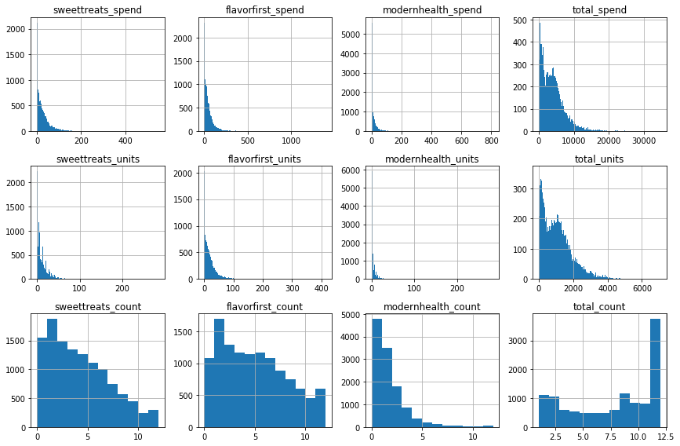

```python
#Histogram: number of person in each segment
segment = ['sweettreats', 'flavorfirst', 'modernhealth','total']
fig, axes = plt.subplots(nrows=3, ncols=4, figsize=(12, 8))
fig.subplots_adjust(bottom=0.2)
n_bins = 200
for i in range(4):
#     print(i)
    df[segment[i]+"_spend"].hist(bins=n_bins,ax=axes[0, i])
    df[segment[i]+"_units"].hist(bins=n_bins,ax=axes[1, i])
    df[segment[i]+"_count"].hist(bins=12,ax=axes[2, i])
    axes[0,i].set_title(segment[i]+"_spend")
    axes[1,i].set_title(segment[i]+"_units")
    axes[2,i].set_title(segment[i]+"_count")

#     1-df[segment[i]+"_spend"].astype(bool).sum(axis=0)/len(df[target_var_list])

#     axes[0,i].set_xscale('log')
#     axes[1,i].set_xscale('log')
#     axes[0,i].set_yscale('log')
#     axes[1,i].set_yscale('log')
plt.tight_layout()
```

### 1.2 Define modeling variables

- define explantory variables (predictor), target variables (response), and variables for normalization, etc.
- target variables are spending features of the 3 segments: sweettreats, flavorfirst and modernhealth.
- normalization variable consider high spending is correlated with high units and counts.
- exposure variable is a feature in tweedie model that defines a span of time interval.

```python
#Define explantory variable, target variable, variable for normalization, etc
target_var_list = ['sweettreats_spend','sweettreats_units', 'sweettreats_count',
                   'flavorfirst_spend','flavorfirst_units', 'flavorfirst_count',
                   'modernhealth_spend','modernhealth_units', 'modernhealth_count',
                   ]
normalize_var_list = ['total_units','total_spend','total_count']
exclude_list = ['countintab',]
# exposure_var for tweedie model
exposure_var = 'total_count'
df_X = df[df.columns[~df.columns.isin(target_var_list+exclude_list+normalize_var_list)]]
```

```python
#Count 0 values
len(df[target_var_list+normalize_var_list])-df[target_var_list+normalize_var_list].astype(bool).sum(axis=0)
```

```
sweettreats_spend     1551
sweettreats_units     1551
sweettreats_count     1551
flavorfirst_spend     1078
flavorfirst_units     1078
flavorfirst_count     1078
modernhealth_spend    4782
modernhealth_units    4782
modernhealth_count    4782
total_units              0
total_spend              0
total_count              0
dtype: int64
```

```python
#Fraction of 0 values
1-df[target_var_list+normalize_var_list].astype(bool).sum(axis=0)/len(df[target_var_list+normalize_var_list])
```

```
sweettreats_spend     0.130216
sweettreats_units     0.130216
sweettreats_count     0.130216
flavorfirst_spend     0.090505
flavorfirst_units     0.090505
flavorfirst_count     0.090505
modernhealth_spend    0.401478
modernhealth_units    0.401478
modernhealth_count    0.401478
total_units           0.000000
total_spend           0.000000
total_count           0.000000
dtype: float64
```

### 1.3 Correlation analysis

- segment spending mostly correlates with segment units.
- among total spending features, segment spending also mostly correlates with total units.
- making total units a potential normalizing variable.

```python
# Correlation of columns
# It shows spending and units are highly correlated in each segment >0.9
# It also shows relative high correlation ~0.7 between counts (the number of months someone purchase) and total segment spending and units
# Lastly it still shows some correlation between total unit and spending with each
df[target_var_list+normalize_var_list].corr()
```

|  | sweettreats_spend | sweettreats_units | sweettreats_count | flavorfirst_spend | flavorfirst_units | flavorfirst_count | modernhealth_spend | modernhealth_units | modernhealth_count | total_units | total_spend | total_count |
| --- | --- | --- | --- | --- | --- | --- | --- | --- | --- | --- | --- | --- |
| sweettreats_spend | 1.000000 | 0.944567 | 0.806939 | 0.502404 | 0.532852 | 0.612998 | 0.191311 | 0.201553 | 0.311025 | 0.736983 | 0.689879 | 0.528699 |
| sweettreats_units | 0.944567 | 1.000000 | 0.798008 | 0.487731 | 0.539941 | 0.607833 | 0.179067 | 0.195922 | 0.303163 | 0.718705 | 0.642025 | 0.520072 |
| sweettreats_count | 0.806939 | 0.798008 | 1.000000 | 0.544503 | 0.588013 | 0.778992 | 0.235643 | 0.249474 | 0.399624 | 0.818791 | 0.764791 | 0.752771 |
| flavorfirst_spend | 0.502404 | 0.487731 | 0.544503 | 1.000000 | 0.934917 | 0.721034 | 0.325575 | 0.363272 | 0.434196 | 0.647844 | 0.606140 | 0.479468 |
| flavorfirst_units | 0.532852 | 0.539941 | 0.588013 | 0.934917 | 1.000000 | 0.756685 | 0.309195 | 0.353734 | 0.420701 | 0.685291 | 0.610533 | 0.507023 |
| flavorfirst_count | 0.612998 | 0.607833 | 0.778992 | 0.721034 | 0.756685 | 1.000000 | 0.303379 | 0.323252 | 0.483659 | 0.826611 | 0.779848 | 0.801028 |
| modernhealth_spend | 0.191311 | 0.179067 | 0.235643 | 0.325575 | 0.309195 | 0.303379 | 1.000000 | 0.956081 | 0.769472 | 0.333841 | 0.338784 | 0.265214 |
| modernhealth_units | 0.201553 | 0.195922 | 0.249474 | 0.363272 | 0.353734 | 0.323252 | 0.956081 | 1.000000 | 0.765824 | 0.341795 | 0.330939 | 0.270884 |
| modernhealth_count | 0.311025 | 0.303163 | 0.399624 | 0.434196 | 0.420701 | 0.483659 | 0.769472 | 0.765824 | 1.000000 | 0.488162 | 0.479881 | 0.440629 |
| total_units | 0.736983 | 0.718705 | 0.818791 | 0.647844 | 0.685291 | 0.826611 | 0.333841 | 0.341795 | 0.488162 | 1.000000 | 0.958714 | 0.773995 |
| total_spend | 0.689879 | 0.642025 | 0.764791 | 0.606140 | 0.610533 | 0.779848 | 0.338784 | 0.330939 | 0.479881 | 0.958714 | 1.000000 | 0.760247 |
| total_count | 0.528699 | 0.520072 | 0.752771 | 0.479468 | 0.507023 | 0.801028 | 0.265214 | 0.270884 | 0.440629 | 0.773995 | 0.760247 | 1.000000 |

```python
#The goal of next few cells is to explore the correlation in order to determine the normalization variable
```

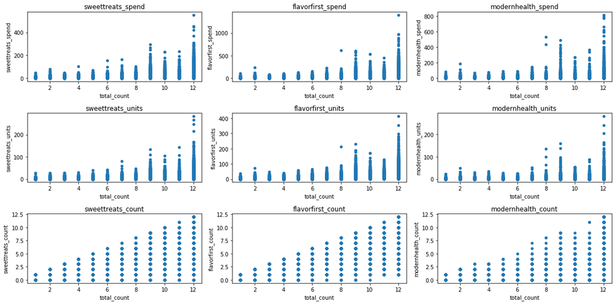

```python
#Explore the relationship between total shopping months and each segment, showing high frequent shopper can buy little

segment = ['sweettreats', 'flavorfirst', 'modernhealth']
fig, axes = plt.subplots(nrows=3, ncols=3, figsize=(16, 8))
fig.subplots_adjust(bottom=0.2)
n_bins = 200
for i in range(3):

    df.plot.scatter(x='total_count',y=segment[i]+"_spend", ax=axes[0, i])
    df.plot.scatter(x='total_count',y=segment[i]+"_units", ax=axes[1, i])
    df.plot.scatter(x='total_count',y=segment[i]+"_count", ax=axes[2, i])
    axes[0,i].set_title(segment[i]+"_spend")
    axes[1,i].set_title(segment[i]+"_units")
    axes[2,i].set_title(segment[i]+"_count")

plt.tight_layout()
```

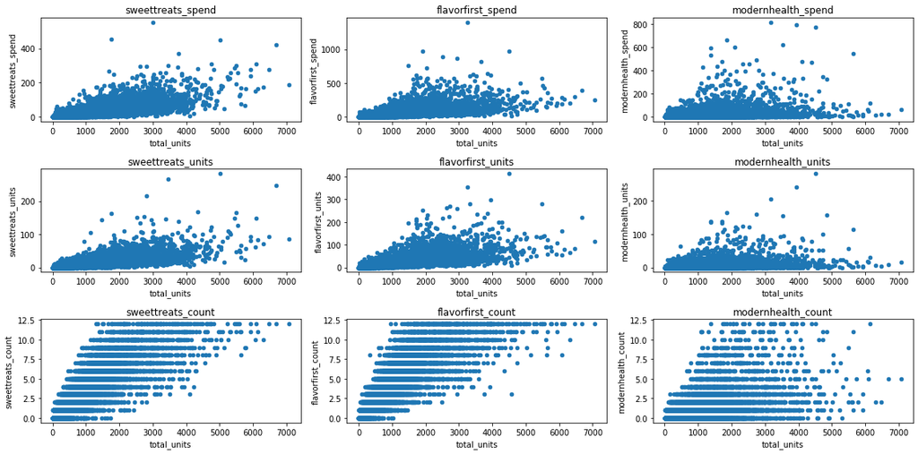

```python
#Explore the relationship between total shopping units and each segment, showing high correlation between two

segment = ['sweettreats', 'flavorfirst', 'modernhealth']
fig, axes = plt.subplots(nrows=3, ncols=3, figsize=(16, 8))
fig.subplots_adjust(bottom=0.2)
n_bins = 200
for i in range(3):

    df.plot.scatter(x='total_units',y=segment[i]+"_spend", ax=axes[0, i])
    df.plot.scatter(x='total_units',y=segment[i]+"_units", ax=axes[1, i])
    df.plot.scatter(x='total_units',y=segment[i]+"_count", ax=axes[2, i])
    axes[0,i].set_title(segment[i]+"_spend")
    axes[1,i].set_title(segment[i]+"_units")
    axes[2,i].set_title(segment[i]+"_count")

plt.tight_layout()
```

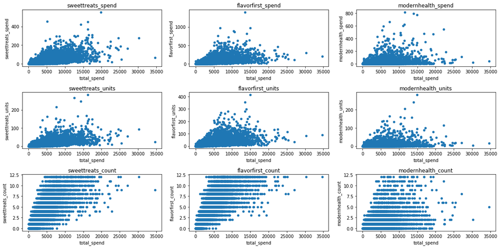

```python
#Explore the relationship between total shopping spend and each segment, showing also high correlation

segment = ['sweettreats', 'flavorfirst', 'modernhealth']
fig, axes = plt.subplots(nrows=3, ncols=3, figsize=(16, 8))
fig.subplots_adjust(bottom=0.2)
n_bins = 200
for i in range(3):

    df.plot.scatter(x='total_spend',y=segment[i]+"_spend", ax=axes[0, i])
    df.plot.scatter(x='total_spend',y=segment[i]+"_units", ax=axes[1, i])
    df.plot.scatter(x='total_spend',y=segment[i]+"_count", ax=axes[2, i])
    axes[0,i].set_title(segment[i]+"_spend")
    axes[1,i].set_title(segment[i]+"_units")
    axes[2,i].set_title(segment[i]+"_count")

plt.tight_layout()
```

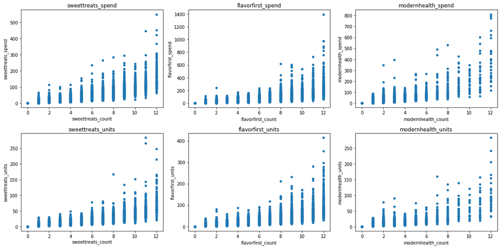

```python
#Alternatively, we can use the purchase count (number of months someone purchase in that segment) in each segment as the normalization column, because even high frequent shopper can bought little in segment
#nevertheless, we would just use the total shopping frequency as normalization in this study

segment = ['sweettreats', 'flavorfirst', 'modernhealth']
fig, axes = plt.subplots(nrows=2, ncols=3, figsize=(16, 8))
fig.subplots_adjust(bottom=0.2)
n_bins = 200
for i in range(3):

    df.plot.scatter(x=segment[i]+"_count",y=segment[i]+"_spend", ax=axes[0, i])
    df.plot.scatter(x=segment[i]+"_count",y=segment[i]+"_units", ax=axes[1, i])
#     df.plot.scatter(x='total_count',y=segment[i]+"_count", ax=axes[2, i])
    axes[0,i].set_title(segment[i]+"_spend")
    axes[1,i].set_title(segment[i]+"_units")
#     axes[2,i].set_title(segment[i]+"_count")

plt.tight_layout()
```

# Step2: Prepare final dataset for modeling

## 2.1 Remove outliers

- having observed the long tail in most spending features
- it is worth to consider removing outliers

```python
df.shape
```

```
(11911, 88)
```

```python
df_X.shape
```

```
(11911, 75)
```

```python
df[target_var_list].describe()
```

|  | sweettreats_spend | sweettreats_units | sweettreats_count | flavorfirst_spend | flavorfirst_units | flavorfirst_count | modernhealth_spend | modernhealth_units | modernhealth_count |
| --- | --- | --- | --- | --- | --- | --- | --- | --- | --- |
| count | 11911.000000 | 11911.000000 | 11911.000000 | 11911.000000 | 11911.000000 | 11911.000000 | 11911.000000 | 11911.000000 | 11911.000000 |
| mean | 28.675214 | 12.730753 | 3.779280 | 52.063524 | 21.093454 | 4.504744 | 16.400372 | 4.742759 | 1.273697 |
| std | 34.739969 | 15.367798 | 2.973134 | 68.427336 | 25.520434 | 3.252739 | 37.330782 | 10.411039 | 1.719248 |
| min | 0.000000 | 0.000000 | 0.000000 | 0.000000 | 0.000000 | 0.000000 | 0.000000 | 0.000000 | 0.000000 |
| 25% | 5.745000 | 3.000000 | 1.000000 | 11.080000 | 5.000000 | 2.000000 | 0.000000 | 0.000000 | 0.000000 |
| 50% | 18.510000 | 8.000000 | 3.000000 | 32.600000 | 14.000000 | 4.000000 | 5.240000 | 2.000000 | 1.000000 |
| 75% | 38.805000 | 17.000000 | 6.000000 | 67.280000 | 28.000000 | 7.000000 | 19.280000 | 6.000000 | 2.000000 |
| max | 550.360000 | 284.000000 | 12.000000 | 1394.600000 | 415.000000 | 12.000000 | 811.180000 | 283.000000 | 12.000000 |

```python
q = df[target_var_list].quantile([.01, .5, 0.99])
q
```

|  | sweettreats_spend | sweettreats_units | sweettreats_count | flavorfirst_spend | flavorfirst_units | flavorfirst_count | modernhealth_spend | modernhealth_units | modernhealth_count |
| --- | --- | --- | --- | --- | --- | --- | --- | --- | --- |
| 0.01 | 0.000 | 0.0 | 0.0 | 0.00 | 0.0 | 0.0 | 0.000 | 0.0 | 0.0 |
| 0.50 | 18.510 | 8.0 | 3.0 | 32.60 | 14.0 | 4.0 | 5.240 | 2.0 | 1.0 |
| 0.99 | 161.864 | 68.9 | 11.0 | 332.33 | 122.0 | 12.0 | 153.476 | 45.0 | 9.0 |

```python
#Define 99 quantile, showing large difference between maximum values and 99 quantile!
q99 = q.loc[0.99]
q99
```

```
sweettreats_spend     161.864
sweettreats_units      68.900
sweettreats_count      11.000
flavorfirst_spend     332.330
flavorfirst_units     122.000
flavorfirst_count      12.000
modernhealth_spend    153.476
modernhealth_units     45.000
modernhealth_count      9.000
Name: 0.99, dtype: float64
```

```python
#total number of households that are under 99 quantile across all segments
(df[target_var_list]<=q99).all(axis=1).sum()
```

```
11447
```

```python
df_adopt = df[(df[target_var_list]<=q99).all(axis=1)]
```

```python
df_adopt.head()
```

| hhid | designated_market_area_rank | local_county_size_code | residence_in_metro_county_flag | prizm_segment_nickname | psycle_segment_nickname | connexions_segment_nickname | spectra_reportable_classification_code | residence_ownership_status_desc | residence_structure_type_code | owns_secondary_residence_flag | ... | total_count | sweettreats_spend | sweettreats_units | sweettreats_count | flavorfirst_spend | flavorfirst_units | flavorfirst_count | modernhealth_spend | modernhealth_units | modernhealth_count |
| --- | --- | --- | --- | --- | --- | --- | --- | --- | --- | --- | --- | --- | --- | --- | --- | --- | --- | --- | --- | --- | --- |
| 15619 | 9 | A | Y | Winner's Circle | Bargain Lovers | The Pragmatics | 0 | Owned | 1 | N | ... | 12 | 23.37 | 10.0 | 5 | 51.17 | 23.0 | 9 | 35.04 | 10.0 | 3 |
| 15790 | 9 | A | Y | Movers & Shakers | Business Class | Analoggers | 0 | Owned | 1 | N | ... | 11 | 22.31 | 10.0 | 4 | 22.05 | 8.0 | 4 | 28.63 | 9.0 | 2 |
| 18024 | 9 | A | Y | Upper Crust | Business Class | Analoggers | 0 | Owned | 1 | Y | ... | 8 | 29.18 | 11.0 | 5 | 34.91 | 14.0 | 3 | 31.95 | 13.0 | 1 |
| 21220 | 2 | A | Y | Money & Brains | Safe at Home | Broadband Boulevards | 0 | Owned | 1 | N | ... | 3 | 0.00 | 0.0 | 0 | 7.63 | 6.0 | 2 | 0.00 | 0.0 | 0 |
| 25517 | 2 | A | Y | Middleburg Managers | Family Fortunes | Technovators | 0 | Owned | 1 | N | ... | 5 | 9.75 | 5.0 | 1 | 0.00 | 0.0 | 0 | 29.95 | 5.0 | 1 |

5 rows × 88 columns

```python
df_adopt.shape
```

```
(11447, 88)
```

```python
#remove outliers still capture 96% of all
len(df_adopt)/len(df)*100
```

```
96.10444127277307
```

```python
df_adopt[target_var_list].describe()
```

|  | sweettreats_spend | sweettreats_units | sweettreats_count | flavorfirst_spend | flavorfirst_units | flavorfirst_count | modernhealth_spend | modernhealth_units | modernhealth_count |
| --- | --- | --- | --- | --- | --- | --- | --- | --- | --- |
| count | 11447.000000 | 11447.000000 | 11447.000000 | 11447.000000 | 11447.000000 | 11447.000000 | 11447.000000 | 11447.000000 | 11447.000000 |
| mean | 25.401470 | 11.304447 | 3.586355 | 45.088731 | 18.581916 | 4.296497 | 12.952199 | 3.793046 | 1.135581 |
| std | 26.714577 | 11.534858 | 2.803302 | 48.381301 | 19.178230 | 3.109309 | 20.222667 | 5.892706 | 1.416731 |
| min | 0.000000 | 0.000000 | 0.000000 | 0.000000 | 0.000000 | 0.000000 | 0.000000 | 0.000000 | 0.000000 |
| 25% | 5.330000 | 2.000000 | 1.000000 | 10.360000 | 5.000000 | 2.000000 | 0.000000 | 0.000000 | 0.000000 |
| 50% | 17.500000 | 8.000000 | 3.000000 | 30.970000 | 13.000000 | 4.000000 | 4.980000 | 1.000000 | 1.000000 |
| 75% | 36.415000 | 16.000000 | 6.000000 | 62.815000 | 26.000000 | 7.000000 | 17.965000 | 5.000000 | 2.000000 |
| max | 160.260000 | 68.000000 | 11.000000 | 330.420000 | 122.000000 | 12.000000 | 151.340000 | 45.000000 | 9.000000 |

```python
#assign the outlier removed dataset to df
df = df_adopt
```

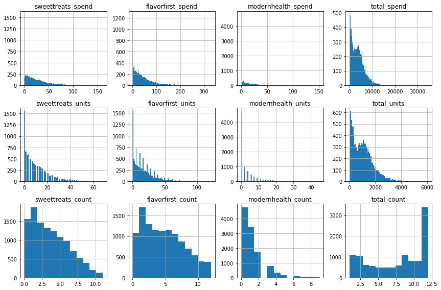

```python
#compare to previous, the x value largely retrace to the left
segment = ['sweettreats', 'flavorfirst', 'modernhealth','total']
fig, axes = plt.subplots(nrows=3, ncols=4, figsize=(12, 8))
fig.subplots_adjust(bottom=0.2)
n_bins = [200,100,12]
for i in range(4):
#     print(i)
    df[segment[i]+"_spend"].hist(bins=n_bins[0],ax=axes[0, i])
    df[segment[i]+"_units"].hist(bins=n_bins[1],ax=axes[1, i])
    df[segment[i]+"_count"].hist(bins=n_bins[2],ax=axes[2, i])
    axes[0,i].set_title(segment[i]+"_spend")
    axes[1,i].set_title(segment[i]+"_units")
    axes[2,i].set_title(segment[i]+"_count")

#     axes[0,i].set_xscale('log')
#     axes[1,i].set_xscale('log')
#     axes[0,i].set_yscale('log')
#     axes[1,i].set_yscale('log')
plt.tight_layout()
```

### 2.2 Explanotory variable selection

- further divide the predictors to categorical and numerical variables
- automatic determination and manual correction of variable types

```python
#check variable type, there are two types
df_X.dtypes.unique()
```

```
array([dtype('int64'), dtype('O')], dtype=object)
```

```python
# initialize two types of variables
catogory_var_list = []
numeric_var_list = []
```

```python
catogory_var_list += df_X.select_dtypes(include=['category','object']).columns.tolist()
catogory_var_list = list(set(catogory_var_list))
# df[catogory_var_list]=df[catogory_var_list].astype('object')
```

```python
catogory_var_list.sort()
catogory_var_list
```

```
['cable_plus_flag',
 'connexions_segment_nickname',
 'female_head_of_house_present_flag',
 'has_domestic_vehicle_flag',
 'has_foreign_vehicle_flag',
 'has_game_attached_to_tv_flag',
 'has_internet_access_flag',
 'has_internet_capable_digital_device_flag',
 'has_tv_with_high_definition_display_capability_flag',
 'head_of_house_present_flag',
 'internet_connection_speed_desc',
 'is_african_american_residence_flag',
 'is_american_indian_residence_flag',
 'is_asian_residence_flag',
 'is_hawaiian_residence_flag',
 'is_high_definition_capable_and_receivable_flag',
 'is_multiple_income_residence_flag',
 'is_non_working_residence_flag',
 'is_other_race_residence_flag',
 'is_single_income_residence_flag',
 'is_white_residence_flag',
 'keeps_cats_flag',
 'keeps_dogs_flag',
 'language_classification_desc',
 'local_county_size_code',
 'male_head_of_house_present_flag',
 'operable_tv_category_desc',
 'owns_personal_computer_flag',
 'owns_secondary_residence_flag',
 'pay_cable_flag',
 'presence_of_non_adults_under_age_18_flag',
 'prizm_segment_nickname',
 'psycle_segment_nickname',
 'purchased_bottled_water_flag',
 'purchased_coffee_or_tea_flag',
 'purchased_soft_drinks_flag',
 'purchased_table_wine_flag',
 'residence_in_metro_county_flag',
 'residence_ownership_status_desc',
 'telephone_capability_desc']
```

```python
numeric_var_list += df_X.select_dtypes(exclude=['category','object']).columns.tolist()
# numeric_var_list = list(set(numeric_var_list)- set(catogory_var_list))
```

```python
numeric_var_list.sort()
numeric_var_list
```

```
['annual_income_mid_point_in_thousands',
 'designated_market_area_rank',
 'head_of_house_education_category_code',
 'head_of_house_ethnic_identity_code',
 'head_of_house_nielsen_occupation_category_code',
 'head_of_house_race_category_code',
 'head_of_house_working_hours_per_week',
 'number_of_adults_age_18_plus',
 'number_of_cars',
 'number_of_children_age_12_to_17',
 'number_of_children_under_age_12',
 'number_of_children_under_age_2',
 'number_of_children_under_age_3',
 'number_of_children_under_age_6',
 'number_of_females',
 'number_of_females_age_12_to_17',
 'number_of_females_age_18_plus',
 'number_of_females_age_2_to_5',
 'number_of_females_age_6_to_11',
 'number_of_full_time_working_women',
 'number_of_males',
 'number_of_males_age_12_to_17',
 'number_of_males_age_18_to_34',
 'number_of_males_age_2_to_5',
 'number_of_males_age_35_to_49',
 'number_of_males_age_50_plus',
 'number_of_males_age_6_to_11',
 'number_of_non_adults_under_age_18',
 'number_of_part_time_working_women',
 'number_of_persons',
 'number_of_trucks',
 'number_of_tv_sets_that_are_viewable',
 'number_of_working_women',
 'residence_structure_type_code',
 'spectra_reportable_classification_code']
```

```python
# visual inspection to identify variables with the wrong type, should be
actual_catogory_var_list = \
['head_of_house_education_category_code',
 'head_of_house_nielsen_occupation_category_code',
 'head_of_house_ethnic_identity_code',
 'head_of_house_race_category_code',
 'residence_structure_type_code',
 'spectra_reportable_classification_code']

actual_numeric_var_list = []
```

```python
#modify actual_catogory_var_list and actual_numeric_var_list, rerun this until no miss typed variable in two type of variables
numeric_var_list = list(set(numeric_var_list+actual_numeric_var_list)- set(actual_catogory_var_list))
catogory_var_list = list(set(catogory_var_list+actual_catogory_var_list)- set(actual_numeric_var_list))
```

```python
catogory_var_list.sort()
catogory_var_list
```

```
['cable_plus_flag',
 'connexions_segment_nickname',
 'female_head_of_house_present_flag',
 'has_domestic_vehicle_flag',
 'has_foreign_vehicle_flag',
 'has_game_attached_to_tv_flag',
 'has_internet_access_flag',
 'has_internet_capable_digital_device_flag',
 'has_tv_with_high_definition_display_capability_flag',
 'head_of_house_education_category_code',
 'head_of_house_ethnic_identity_code',
 'head_of_house_nielsen_occupation_category_code',
 'head_of_house_present_flag',
 'head_of_house_race_category_code',
 'internet_connection_speed_desc',
 'is_african_american_residence_flag',
 'is_american_indian_residence_flag',
 'is_asian_residence_flag',
 'is_hawaiian_residence_flag',
 'is_high_definition_capable_and_receivable_flag',
 'is_multiple_income_residence_flag',
 'is_non_working_residence_flag',
 'is_other_race_residence_flag',
 'is_single_income_residence_flag',
 'is_white_residence_flag',
 'keeps_cats_flag',
 'keeps_dogs_flag',
 'language_classification_desc',
 'local_county_size_code',
 'male_head_of_house_present_flag',
 'operable_tv_category_desc',
 'owns_personal_computer_flag',
 'owns_secondary_residence_flag',
 'pay_cable_flag',
 'presence_of_non_adults_under_age_18_flag',
 'prizm_segment_nickname',
 'psycle_segment_nickname',
 'purchased_bottled_water_flag',
 'purchased_coffee_or_tea_flag',
 'purchased_soft_drinks_flag',
 'purchased_table_wine_flag',
 'residence_in_metro_county_flag',
 'residence_ownership_status_desc',
 'residence_structure_type_code',
 'spectra_reportable_classification_code',
 'telephone_capability_desc']
```

```python
numeric_var_list.sort()
numeric_var_list
```

```
['annual_income_mid_point_in_thousands',
 'designated_market_area_rank',
 'head_of_house_working_hours_per_week',
 'number_of_adults_age_18_plus',
 'number_of_cars',
 'number_of_children_age_12_to_17',
 'number_of_children_under_age_12',
 'number_of_children_under_age_2',
 'number_of_children_under_age_3',
 'number_of_children_under_age_6',
 'number_of_females',
 'number_of_females_age_12_to_17',
 'number_of_females_age_18_plus',
 'number_of_females_age_2_to_5',
 'number_of_females_age_6_to_11',
 'number_of_full_time_working_women',
 'number_of_males',
 'number_of_males_age_12_to_17',
 'number_of_males_age_18_to_34',
 'number_of_males_age_2_to_5',
 'number_of_males_age_35_to_49',
 'number_of_males_age_50_plus',
 'number_of_males_age_6_to_11',
 'number_of_non_adults_under_age_18',
 'number_of_part_time_working_women',
 'number_of_persons',
 'number_of_trucks',
 'number_of_tv_sets_that_are_viewable',
 'number_of_working_women']
```

```python
#check variable with single value and all unique responses
catogory_single_response_list = []
for i in catogory_var_list:
    response = df[i].unique()
    print(i,'-->',response,'\n')
    if len(response) == 1:
        catogory_single_response_list.append(i)
```

```
cable_plus_flag --> ['Y' 'N']

connexions_segment_nickname --> ['The Pragmatics' 'Analoggers' 'Broadband Boulevards' 'Technovators'
 'Antenna Land' 'Cyber Sophisticates' 'Gadgets Galore' 'Discounts & Deals'
 'Dish Country' 'Low-Speed Boomers' 'Gearing Up' 'Tech Skeptics'
 'Bucolic Basics' 'Generation WiFi' 'WiFi Warriors' 'Bundled Burbs'
 'Calling Circles' 'Connected Country' 'Leisurely Adopters' 'IM Nation'
 'The Unconnected' 'Internet Hinterlands' 'Smart Gamers' 'Opting Out'
 'Time Shifters' 'Multimedia Families' 'Satellites & Silos' 'Dial-Up Duos'
 'Video Homebodies' 'High-Tech Society' 'Techs and the City'
 'Last to Adopt' 'Low-Tech Country' 'Cinemaniacs' 'New Technorati'
 'Plugged-In Families' 'New Kids on the Grid' 'Kids & Keyboards'
 'Tech Nests' 'Video Vistas' 'Digital Dreamers' 'Landline Living'
 'You & I Tunes' 'Tech-Free Frontier' 'Techtown Lites'
 'Rural Transmissions' 'Cyber Strivers' 'Old-Time Media' 'Family Dishes'
 'Big City, Small Tech' 'Plug & Play' 'Satellite Seniors' 'Early-Bird TV']

female_head_of_house_present_flag --> ['N' 'Y']

has_domestic_vehicle_flag --> ['N' 'Y']

has_foreign_vehicle_flag --> ['Y' 'N']

has_game_attached_to_tv_flag --> ['N' 'Y']

has_internet_access_flag --> ['Y' 'N']

has_internet_capable_digital_device_flag --> ['Y' 'N']

has_tv_with_high_definition_display_capability_flag --> ['Y' 'N']

head_of_house_education_category_code --> [15 18 16 19 13 11 20 10 12 14  0  9  8]

head_of_house_ethnic_identity_code --> [1 2]

head_of_house_nielsen_occupation_category_code --> [8 1 0 4 2 6 7 5 3]

head_of_house_present_flag --> ['Y']

head_of_house_race_category_code --> [ 1  6  2 11  3  9  8  4  5 10  7]
```

[output cut: 85 more lines]

```
purchased_coffee_or_tea_flag --> ['Y' 'N']

purchased_soft_drinks_flag --> ['Y' 'N']

purchased_table_wine_flag --> ['Y' 'N']

residence_in_metro_county_flag --> ['Y' 'N']

residence_ownership_status_desc --> ['Owned' 'Rented']

residence_structure_type_code --> [1 2 3]

spectra_reportable_classification_code --> [0]

telephone_capability_desc --> ['Cell Only' 'Cell and Land' 'Landline Only' 'No Phone']
```

```python
catogory_single_response_list
```

```
['head_of_house_present_flag',
 'internet_connection_speed_desc',
 'spectra_reportable_classification_code']
```

```python
#remove catogory variable input to model based on review of unique response and later VIF analysis
catogory_var_list_exclude = catogory_single_response_list+\
['prizm_segment_nickname',
 'connexions_segment_nickname',
 'psycle_segment_nickname',
 'is_single_income_residence_flag',
#  'is_non_working_residence_flag',
 'is_white_residence_flag',
 'head_of_house_education_category_code',
 'head_of_house_race_category_code'
]
```

```python
catogory_var_list_adopt = list(set(catogory_var_list) - set(catogory_var_list_exclude))
```

```python
catogory_var_list_adopt.sort()
catogory_var_list_adopt
```

```
['cable_plus_flag',
 'female_head_of_house_present_flag',
 'has_domestic_vehicle_flag',
 'has_foreign_vehicle_flag',
 'has_game_attached_to_tv_flag',
 'has_internet_access_flag',
 'has_internet_capable_digital_device_flag',
 'has_tv_with_high_definition_display_capability_flag',
 'head_of_house_ethnic_identity_code',
 'head_of_house_nielsen_occupation_category_code',
 'is_african_american_residence_flag',
 'is_american_indian_residence_flag',
 'is_asian_residence_flag',
 'is_hawaiian_residence_flag',
 'is_high_definition_capable_and_receivable_flag',
 'is_multiple_income_residence_flag',
 'is_non_working_residence_flag',
 'is_other_race_residence_flag',
 'keeps_cats_flag',
 'keeps_dogs_flag',
 'language_classification_desc',
 'local_county_size_code',
 'male_head_of_house_present_flag',
 'operable_tv_category_desc',
 'owns_personal_computer_flag',
 'owns_secondary_residence_flag',
 'pay_cable_flag',
 'presence_of_non_adults_under_age_18_flag',
 'purchased_bottled_water_flag',
 'purchased_coffee_or_tea_flag',
 'purchased_soft_drinks_flag',
 'purchased_table_wine_flag',
 'residence_in_metro_county_flag',
 'residence_ownership_status_desc',
 'residence_structure_type_code',
 'telephone_capability_desc']
```

```python
numeric_var_list.sort()
numeric_var_list
```

```
['annual_income_mid_point_in_thousands',
 'designated_market_area_rank',
 'head_of_house_working_hours_per_week',
 'number_of_adults_age_18_plus',
 'number_of_cars',
 'number_of_children_age_12_to_17',
 'number_of_children_under_age_12',
 'number_of_children_under_age_2',
 'number_of_children_under_age_3',
 'number_of_children_under_age_6',
 'number_of_females',
 'number_of_females_age_12_to_17',
 'number_of_females_age_18_plus',
 'number_of_females_age_2_to_5',
 'number_of_females_age_6_to_11',
 'number_of_full_time_working_women',
 'number_of_males',
 'number_of_males_age_12_to_17',
 'number_of_males_age_18_to_34',
 'number_of_males_age_2_to_5',
 'number_of_males_age_35_to_49',
 'number_of_males_age_50_plus',
 'number_of_males_age_6_to_11',
 'number_of_non_adults_under_age_18',
 'number_of_part_time_working_women',
 'number_of_persons',
 'number_of_trucks',
 'number_of_tv_sets_that_are_viewable',
 'number_of_working_women']
```

```python
#check variable with single value and all unique responses
numeric_single_response_list = []
for i in numeric_var_list:
    response = df[i].nunique()
    print(i,'-->',response,'\n')
    if response == 1:
        numeric_single_response_list.append(i)
```

```
annual_income_mid_point_in_thousands --> 97

designated_market_area_rank --> 177

head_of_house_working_hours_per_week --> 78

number_of_adults_age_18_plus --> 9

number_of_cars --> 9

number_of_children_age_12_to_17 --> 5

number_of_children_under_age_12 --> 8

number_of_children_under_age_2 --> 3

number_of_children_under_age_3 --> 4

number_of_children_under_age_6 --> 6

number_of_females --> 10

number_of_females_age_12_to_17 --> 4

number_of_females_age_18_plus --> 6

number_of_females_age_2_to_5 --> 4

number_of_females_age_6_to_11 --> 5

number_of_full_time_working_women --> 5

number_of_males --> 9

number_of_males_age_12_to_17 --> 5

number_of_males_age_18_to_34 --> 7

number_of_males_age_2_to_5 --> 4

number_of_males_age_35_to_49 --> 5

number_of_males_age_50_plus --> 5

number_of_males_age_6_to_11 --> 6

number_of_non_adults_under_age_18 --> 9

number_of_part_time_working_women --> 4

number_of_persons --> 13

number_of_trucks --> 8

number_of_tv_sets_that_are_viewable --> 10

number_of_working_women --> 5
```

```python
numeric_single_response_list
```

```
[]
```

```python
#remove numeric variable input to model based on review of unique response and later VIF analysis
numeric_var_list_exclude = numeric_single_response_list +\
[
 'number_of_children_age_12_to_17',
 'number_of_children_under_age_12',
 'number_of_children_under_age_2',
 'number_of_children_under_age_3',
#  'number_of_children_under_age_6',
 'number_of_females',
 'number_of_females_age_2_to_5',
#  'number_of_females_age_6_to_11',
#  'number_of_females_age_12_to_17',
#  'number_of_females_age_18_plus',
 'number_of_males',
 'number_of_males_age_2_to_5',
#  'number_of_males_age_6_to_11',
#  'number_of_males_age_12_to_17',
#  'number_of_males_age_18_to_34',
#  'number_of_males_age_35_to_49',
#  'number_of_males_age_50_plus',
 'number_of_persons',
 'number_of_adults_age_18_plus',
 'number_of_working_women',
 'number_of_non_adults_under_age_18'
]
```

```python
numeric_var_list_adopt = list(set(numeric_var_list) - set(numeric_var_list_exclude))
```

```python
numeric_var_list_adopt.sort()
numeric_var_list_adopt
```

```
['annual_income_mid_point_in_thousands',
 'designated_market_area_rank',
 'head_of_house_working_hours_per_week',
 'number_of_cars',
 'number_of_children_under_age_6',
 'number_of_females_age_12_to_17',
 'number_of_females_age_18_plus',
 'number_of_females_age_6_to_11',
 'number_of_full_time_working_women',
 'number_of_males_age_12_to_17',
 'number_of_males_age_18_to_34',
 'number_of_males_age_35_to_49',
 'number_of_males_age_50_plus',
 'number_of_males_age_6_to_11',
 'number_of_part_time_working_women',
 'number_of_trucks',
 'number_of_tv_sets_that_are_viewable']
```

```
array([[<matplotlib.axes._subplots.AxesSubplot object at 0x7f85daf89ca0>,
      dtype=object)
```

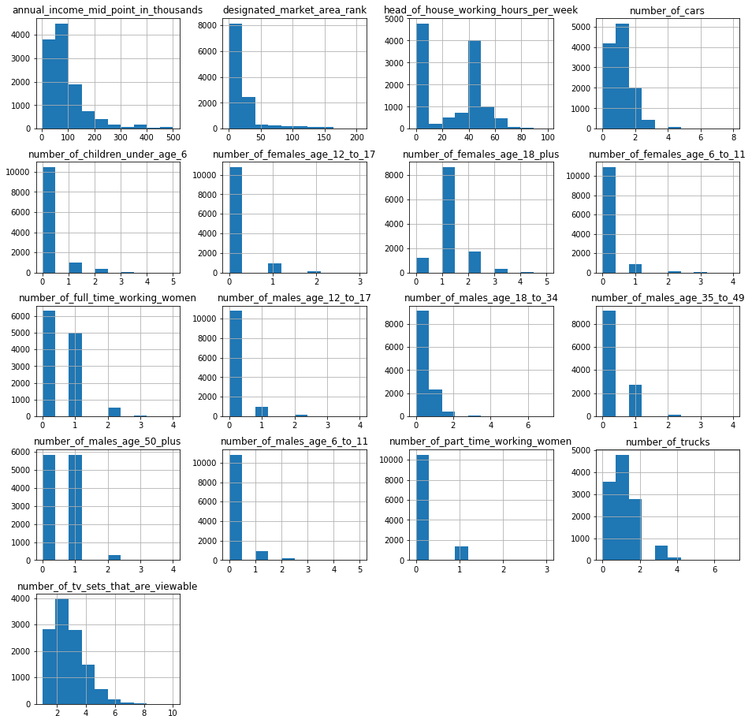

```python
#check numeric variable distribution
df_X[numeric_var_list_adopt].hist(figsize = (16,16))
```

### 2.3 Explanotory variables processing

- use a pipeline to process predictors
- onehot for categorical variables
- binned several numerical variables
- scale some variables

```python
from sklearn.datasets import fetch_openml
from sklearn.compose import ColumnTransformer
from sklearn.linear_model import PoissonRegressor, GammaRegressor
from sklearn.linear_model import TweedieRegressor
from sklearn.metrics import mean_tweedie_deviance
from sklearn.model_selection import train_test_split
from sklearn.pipeline import make_pipeline
from sklearn.preprocessing import FunctionTransformer, OneHotEncoder
from sklearn.preprocessing import StandardScaler, KBinsDiscretizer

from sklearn.metrics import mean_absolute_error, mean_squared_error, auc
```

```python
log_scaled_numeric_var_list = \
['annual_income_mid_point_in_thousands']

binned_numeric_var_list = \
['designated_market_area_rank',
 'head_of_house_working_hours_per_week',
 'number_of_cars',
 'number_of_trucks',
 'number_of_tv_sets_that_are_viewable']
# binned_numeric_var_list = ['binned_numeric']
passthrough_var_list = \
list(set(numeric_var_list_adopt) - set(log_scaled_numeric_var_list+binned_numeric_var_list))
```

```python
log_scale_transformer = make_pipeline(
    FunctionTransformer(func=np.log),
    StandardScaler()
)

column_trans = ColumnTransformer(
    [
        ("binned_numeric", KBinsDiscretizer(n_bins=5,strategy='kmeans'),
            binned_numeric_var_list),
        ("onehot_categorical", OneHotEncoder(),
            catogory_var_list_adopt),
        ("passthrough_numeric", "passthrough",
            passthrough_var_list),
        ("log_scaled_numeric", log_scale_transformer,
            log_scaled_numeric_var_list),
    ],
    remainder="drop",
)
```

```python
#define exploratory data matrix for model
X = column_trans.fit_transform(df)
```

```python
X.shape
```

```
(11447, 124)
```

```python
from sklearn.model_selection import train_test_split

df_train, df_test, X_train, X_test = train_test_split(df, X, test_size=0.2, random_state=0)

# fig, (ax0, ax1, ax2) = plt.subplots(ncols=3, figsize=(16, 4))
# ax0.set_title("df_sweettreats_units")
# _ = df["sweettreats_units"].hist(bins=30, log=True, ax=ax0)
# ax1.set_title("df_train_sweettreats_units")
# _ = df_train["sweettreats_units"].hist(bins=30, log=True, ax=ax1)
# ax2.set_title("df_test_sweettreats_units")
# _ = df_test["sweettreats_units"].hist(bins=30, log=True, ax=ax2)
```

```python
#fraction of 0 values
1-df_test[target_var_list+normalize_var_list].astype(bool).sum(axis=0)/len(df_test[target_var_list+normalize_var_list])
```

```
sweettreats_spend     0.120524
sweettreats_units     0.120524
sweettreats_count     0.120524
flavorfirst_spend     0.095633
flavorfirst_units     0.095633
flavorfirst_count     0.095633
modernhealth_spend    0.411790
modernhealth_units    0.411790
modernhealth_count    0.411790
total_units           0.000000
total_spend           0.000000
total_count           0.000000
dtype: float64
```

# Step3: Modeling

### 3.1 Create model

```python
tweedie_powers = [1.5, 1.7, 1.8, 1.9, 1.99, 1.999, 1.9999]

#create a model for each target segment
model_dict = {}
for i in target_var_list:

    #Use mask to select only positive values, because Tweedie only works in positive values
    mask=df_train[i]>0
    print(i)
    model = TweedieRegressor(power=1.9, alpha=1, max_iter=10000)

    #The response variable is normalized by the exposure variable
    model.fit(X_train[mask], df_train[i][mask],sample_weight=df_train[exposure_var][mask])
    model_dict[i] = model
```

```
sweettreats_spend
sweettreats_units
sweettreats_count
flavorfirst_spend
flavorfirst_units
flavorfirst_count
modernhealth_spend
modernhealth_units
modernhealth_count
```

```python
model_dict
```

```
{'sweettreats_spend': TweedieRegressor(alpha=1, max_iter=10000, power=1.9),
 'sweettreats_units': TweedieRegressor(alpha=1, max_iter=10000, power=1.9),
 'sweettreats_count': TweedieRegressor(alpha=1, max_iter=10000, power=1.9),
 'flavorfirst_spend': TweedieRegressor(alpha=1, max_iter=10000, power=1.9),
 'flavorfirst_units': TweedieRegressor(alpha=1, max_iter=10000, power=1.9),
 'flavorfirst_count': TweedieRegressor(alpha=1, max_iter=10000, power=1.9),
 'modernhealth_spend': TweedieRegressor(alpha=1, max_iter=10000, power=1.9),
 'modernhealth_units': TweedieRegressor(alpha=1, max_iter=10000, power=1.9),
 'modernhealth_count': TweedieRegressor(alpha=1, max_iter=10000, power=1.9)}
```

### 3.2 Print model metrics

```python
# #Define function to print evaluation metrics
# def score_estimator(
#     estimator, X_train, X_test, df_train, df_test, target, exposure,tweedie_powers=None,
# ):
#     """Evaluate an estimator on train and test sets with different metrics"""

#     metrics = [
#         ("D² explained", None),   # Use default scorer if it exists
#         ("mean abs. error", mean_absolute_error),
#         ("mean squared error", mean_squared_error),
#     ]
# #     if tweedie_powers:
# #         metrics += [(
# #             "mean Tweedie dev p={:.4f}".format(power),
# #             partial(mean_tweedie_deviance, power=power)
# #         ) for power in tweedie_powers]

#     res = []
#     for subset_label, X, df in [
#         ("train", X_train, df_train),
#         ("test", X_test, df_test),
#     ]:
#         y = df[target]/df[exposure]
#         for score_label, metric in metrics:
#             if isinstance(estimator, tuple) and len(estimator) == 2:
#                 # Score the model consisting of the product of frequency and
#                 # severity models.
#                 est_freq, est_sev = estimator
#                 y_pred = est_freq.predict(X) * est_sev.predict(X)
#             else:
#                 y_pred = estimator.predict(X)

#             if metric is None:
#                 if not hasattr(estimator, "score"):
#                     continue
#                 score = estimator.score(X, y)
#             else:
#                 score = metric(y, y_pred)

#             res.append(
#                 {"subset": subset_label, "metric": score_label, "score": score}
#             )

#     res = (
#         pd.DataFrame(res)
#         .set_index(["metric", "subset"])
#         .score.unstack(-1)
#         .round(4)
#         .loc[:, ['train', 'test']]
#     )
#     return res
```

```python
def score_estimator(
    estimator, X_train, X_test, df_train, df_test, target, weights,
    tweedie_powers=None,
):
    """Evaluate an estimator on train and test sets with different metrics"""

    metrics = [
        ("D² explained", None),   # Use default scorer if it exists
        ("mean abs. error", mean_absolute_error),
        ("mean squared error", mean_squared_error),
    ]
    if tweedie_powers:
        metrics += [(
            "mean Tweedie dev p={:.4f}".format(power),
            partial(mean_tweedie_deviance, power=power)
        ) for power in tweedie_powers]

    res = []
    for subset_label, X, df in [
        ("train", X_train, df_train),
        ("test", X_test, df_test),
    ]:
        y, _weights = df[target], df[weights]
        for score_label, metric in metrics:
            if isinstance(estimator, tuple) and len(estimator) == 2:
                # Score the model consisting of the product of frequency and
                # severity models.
                est_freq, est_sev = estimator
                y_pred = est_freq.predict(X) * est_sev.predict(X)
            else:
                y_pred = estimator.predict(X)

            if metric is None:
                if not hasattr(estimator, "score"):
                    continue
                score = estimator.score(X, y, sample_weight=_weights)
            else:
                score = metric(y, y_pred, sample_weight=_weights)

            res.append(
                {"subset": subset_label, "metric": score_label, "score": score}
            )

    res = (
        pd.DataFrame(res)
        .set_index(["metric", "subset"])
        .score.unstack(-1)
        .round(4)
        .loc[:, ['train', 'test']]
    )
    return res
```

```python
#Print model metrics
for i in target_var_list:
    scores_model = score_estimator(
        model_dict[i],
        X_train,
        X_test,
        df_train,
        df_test,
        target=i,
        weights = exposure_var,
        tweedie_powers=tweedie_powers,
    )
    print(i,'\n',scores_model,'\n')
```

```
sweettreats_spend
 subset                        train      test
metric
D² explained                 0.0113    0.0149
mean Tweedie dev p=1.5000    4.2516    4.3899
mean Tweedie dev p=1.7000    2.4927    2.5097
mean Tweedie dev p=1.8000    2.0680    2.0404
mean Tweedie dev p=1.9000    2.0783    1.9791
mean Tweedie dev p=1.9900    9.3621    8.2609
mean Tweedie dev p=1.9990   84.9047   73.8745
mean Tweedie dev p=1.9999  840.5610  730.2480
mean abs. error             21.0985   22.2618
mean squared error         746.7109  854.8680

sweettreats_units
 subset                        train      test
metric
D² explained                 0.0114    0.0159
mean Tweedie dev p=1.5000    2.6908    2.7965
mean Tweedie dev p=1.7000    1.8654    1.8885
mean Tweedie dev p=1.8000    1.6873    1.6720
mean Tweedie dev p=1.9000    1.8589    1.7744
mean Tweedie dev p=1.9900    9.2385    8.1522
mean Tweedie dev p=1.9990   84.7887   73.7733
mean Tweedie dev p=1.9999  840.4459  730.1475
mean abs. error              9.0368    9.5898
mean squared error         136.3760  157.4819

sweettreats_count
 subset                        train      test
metric
D² explained                 0.0049    0.0083
mean Tweedie dev p=1.5000    0.9854    0.9559
mean Tweedie dev p=1.7000    0.9160    0.8696
mean Tweedie dev p=1.8000    0.9830    0.9175
mean Tweedie dev p=1.9000    1.3393    1.2184
mean Tweedie dev p=1.9900    8.8459    7.7320
mean Tweedie dev p=1.9990   84.4071   73.3649
mean Tweedie dev p=1.9999  840.0653  729.7402
mean abs. error              2.1642    2.2144
```

[output cut: 70 more lines]

```
mean squared error           45.2792    46.5464

modernhealth_count
 subset                         train       test
metric
D² explained                 -0.0164    -0.0144
mean Tweedie dev p=1.5000     2.0541     2.0663
mean Tweedie dev p=1.7000     2.7395     2.7515
mean Tweedie dev p=1.8000     3.6703     3.6837
mean Tweedie dev p=1.9000     6.5477     6.5676
mean Tweedie dev p=1.9900    58.9967    59.1456
mean Tweedie dev p=1.9990   583.8035   585.2499
mean Tweedie dev p=1.9999  5831.9027  5846.3234
mean abs. error               1.3297     1.3433
mean squared error            2.7066     2.7743
```

### 3.3 Plot prediction vs. actual value

```python
#Define function to print prediction vs true value
def prediction_plot(
    estimator, X_train, X_test, df_train, df_test, target, exposure,tweedie_powers=None,
):
    """Evaluate an estimator on train and test sets with different metrics"""
    print(i)
    res = []
    fig2, axes2 = plt.subplots(nrows=1, ncols=2, figsize=(16, 6), sharey=True)

    for col_num, subset_label, X_use, df in [
        (0, "train", X_train, df_train),
        (1, "test", X_test, df_test),
    ]:
        res.append(
            {
                "subset": subset_label,
                "observed": df[i].values.sum(),
                #the predicted value is scaled with exposure variable
                "predicted":
                np.sum(model_dict[i].predict(X_use)),
            }
        )

        y_true = df[i]
        #the predicted value is scaled with exposure variable
        y_pred = model_dict[i].predict(X_use)
        axes2[col_num].scatter(x=y_true, y=y_pred)
        axes2[col_num].set_title(i+' '+subset_label)

    print(pd.DataFrame(res).set_index("subset").T,'\n')
    return res
```

```python
# def plot_obs_pred(df, feature, weight, observed, predicted, y_label=None,
#                   title=None, ax=None, fill_legend=False):
#     """Plot observed and predicted - aggregated per feature level.

#     Parameters
#     ----------
#     df : DataFrame
#         input data
#     feature: str
#         a column name of df for the feature to be plotted
#     weight : str
#         column name of df with the values of weights or exposure
#     observed : str
#         a column name of df with the observed target
#     predicted : DataFrame
#         a dataframe, with the same index as df, with the predicted target
#     fill_legend : bool, default=False
#         whether to show fill_between legend
#     """
#     # aggregate observed and predicted variables by feature level
#     df_ = df.loc[:, [feature, weight]].copy()
#     df_["observed"] = df[observed] * df[weight]
#     df_["predicted"] = predicted * df[weight]
#     df_ = (
#         df_.groupby([feature])[[weight, "observed", "predicted"]]
#         .sum()
#         .assign(observed=lambda x: x["observed"] / x[weight])
#         .assign(predicted=lambda x: x["predicted"] / x[weight])
#     )

#     ax = df_.loc[:, ["observed", "predicted"]].plot(style=".", ax=ax)
#     y_max = df_.loc[:, ["observed", "predicted"]].values.max() * 0.8
#     p2 = ax.fill_between(
#         df_.index,
#         0,
#         y_max * df_[weight] / df_[weight].values.max(),
#         color="g",
#         alpha=0.1,
#     )
#     if fill_legend:
#         ax.legend([p2], ["{} distribution".format(feature)])
#     ax.set(
#         ylabel=y_label if y_label is not None else None,
#         title=title if title is not None else "Train: Observed vs Predicted",
#     )
```

```python
# for i in target_var_list:
#     plot_obs_pred(
#         df=df_train,
#         feature="DrivAge",
#         weight="Exposure",
#         observed="Frequency",
#         predicted=glm_freq.predict(X_train),
#         y_label="Claim Frequency",
#         title="train data",
#         ax=ax[0, 0],
#     )
#     print(i,'\n',plot_model,'\n')
```

```
sweettreats_spend
subset             train          test
observed   229326.999997  61443.629999
predicted  316057.013502  79414.258597

sweettreats_spend
 [{'subset': 'train', 'observed': 229326.999996674, 'predicted': 316057.0135024661}, {'subset': 'test', 'observed': 61443.629998888, 'predicted': 79414.25859687648}]

sweettreats_units
subset             train          test
observed   102241.000000  27161.000000
predicted  140038.448057  35155.013458

sweettreats_units
 [{'subset': 'train', 'observed': 102241.0, 'predicted': 140038.44805748394}, {'subset': 'test', 'observed': 27161.0, 'predicted': 35155.0134575127}]

sweettreats_count
subset            train          test
observed   32522.000000   8531.000000
predicted  44470.106253  11145.241514

sweettreats_count
 [{'subset': 'train', 'observed': 32522, 'predicted': 44470.10625331883}, {'subset': 'test', 'observed': 8531, 'predicted': 11145.24151354108}]

flavorfirst_spend
subset             train           test
observed   411190.509994  104940.189498
predicted  552910.040818  138194.539462

flavorfirst_spend
 [{'subset': 'train', 'observed': 411190.50999393605, 'predicted': 552910.0408182923}, {'subset': 'test', 'observed': 104940.189498125, 'predicted': 138194.53946174504}]

flavorfirst_units
subset             train         test
observed   169665.360000  43041.83000
predicted  227012.020042  56726.57917

flavorfirst_units
 [{'subset': 'train', 'observed': 169665.36000001003, 'predicted': 227012.020042383}, {'subset': 'test', 'observed': 43041.83, 'predicted': 56726.57916957782}]

```

[output cut: 16 more lines]

```
modernhealth_units
subset            train          test
observed   34702.000000   8717.000000
predicted  62834.948052  15737.641775

modernhealth_units
 [{'subset': 'train', 'observed': 34702.0, 'predicted': 62834.94805169677}, {'subset': 'test', 'observed': 8717.0, 'predicted': 15737.641774540782}]

modernhealth_count
subset            train         test
observed   10345.000000  2654.000000
predicted  18960.118855  4749.426841

modernhealth_count
 [{'subset': 'train', 'observed': 10345, 'predicted': 18960.11885526917}, {'subset': 'test', 'observed': 2654, 'predicted': 4749.426841311977}]
```

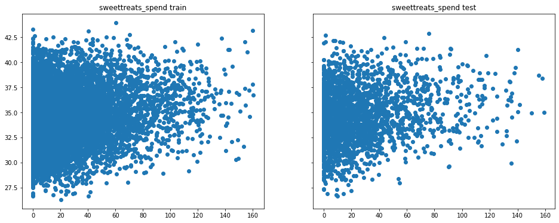

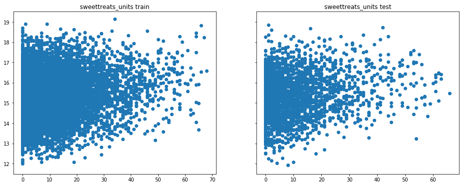

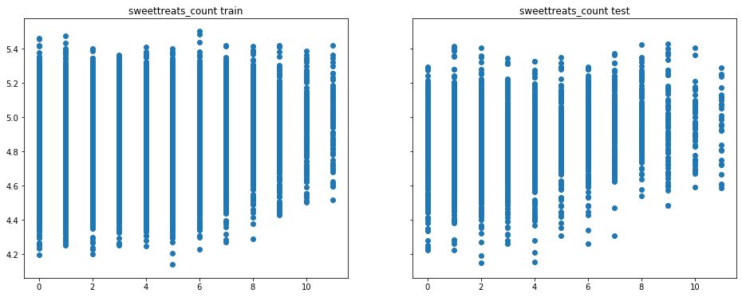

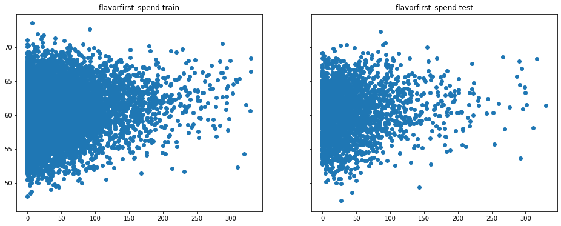

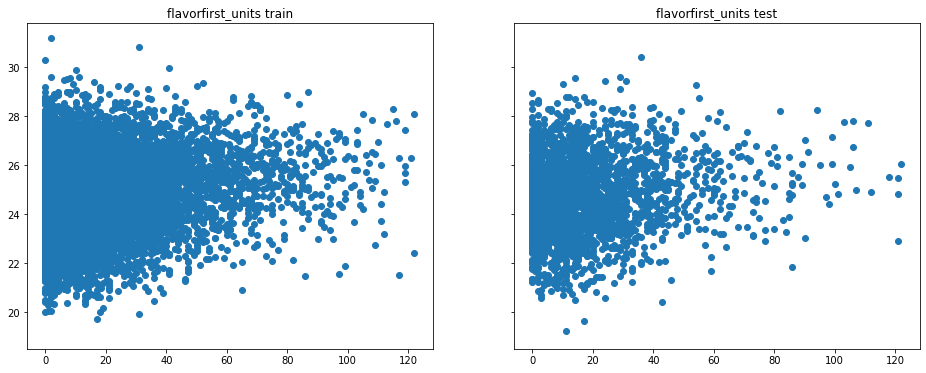

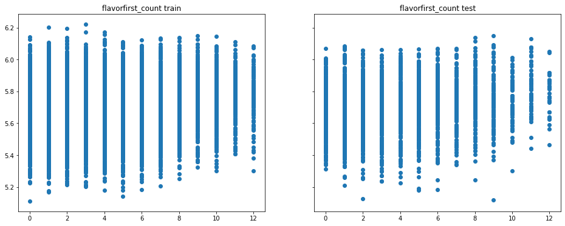

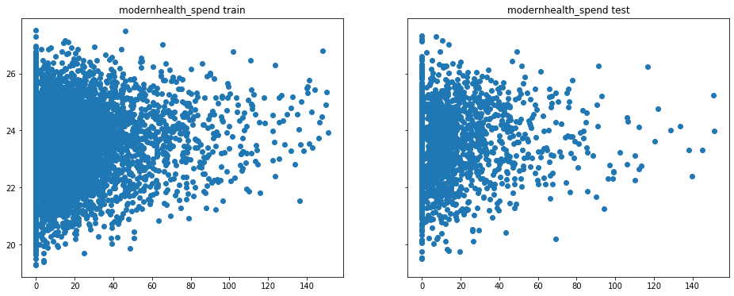

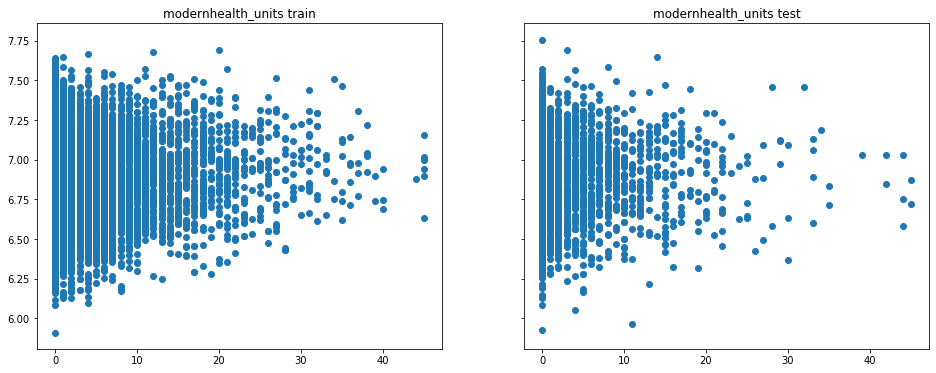

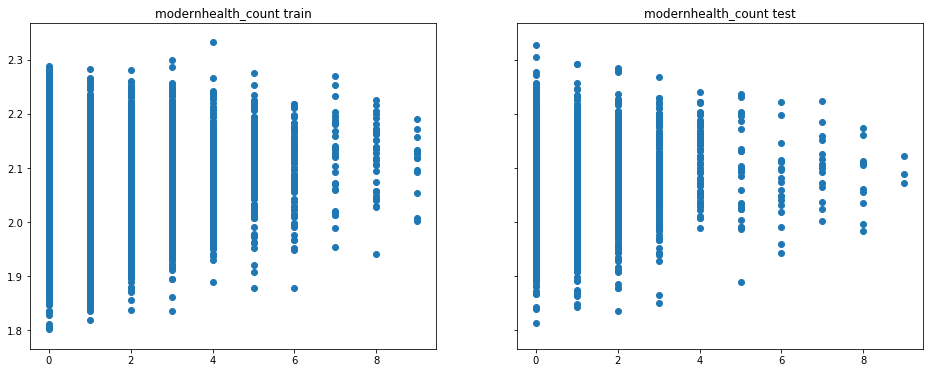

```python
for i in target_var_list:
    plot_model = prediction_plot(
        model_dict[i],
        X_train,
        X_test,
        df_train,
        df_test,
        target=i,
        exposure = exposure_var,
        tweedie_powers=tweedie_powers,
    )
    print(i,'\n',plot_model,'\n')
```

### 3.4 Check prediction vs. actual value at various predictor cross-section

```python
#Define function to plot
def plot_obs_pred(df, X, feature, target, model, exposure, y_label=None,
                  ax=None, fill_legend=False):
    """Plot observed and predicted - aggregated per feature level.

    Parameters
    ----------
    df : DataFrame
        input data
    feature: str
        a column name of df for the feature to be plotted
    weight : str
        column name of df with the values of weights or exposure
    observed : str
        a column name of df with the observed target
    predicted : DataFrame
        a dataframe, with the same index as df, with the predicted target
    fill_legend : bool, default=False
        whether to show fill_between legend
    """

    title = 'test '+ feature

    # aggregate observed and predicted variables by feature level
    df_ = df.loc[:, [feature]].copy()
    df_["observed"] = df[target]
    df_["predicted"] = model.predict(X) *df[exposure]
    df_ = (
        df_.groupby([feature])[["observed", "predicted"]]
        .sum()
        .assign(observed=lambda x: x["observed"])
        .assign(predicted=lambda x: x["predicted"])
    )

    ax = df_.loc[:, ["observed", "predicted"]].plot(style=".", ax=ax)
    y_max = df_.loc[:, ["observed", "predicted"]].values.max() * 0.8
    p2 = ax.fill_between(
        df_.index,
        0,
        y_max,
        color="g",
        alpha=0.1,
    )
    if fill_legend:
        ax.legend([p2], ["{} distribution".format(feature)])
    ax.set(
        ylabel=y_label if y_label is not None else None,
        title=title if title is not None else "Train: Observed vs Predicted",
    )
```

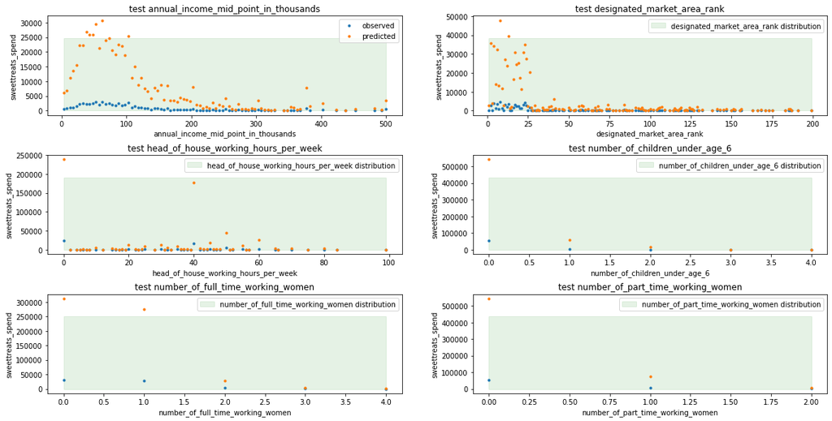

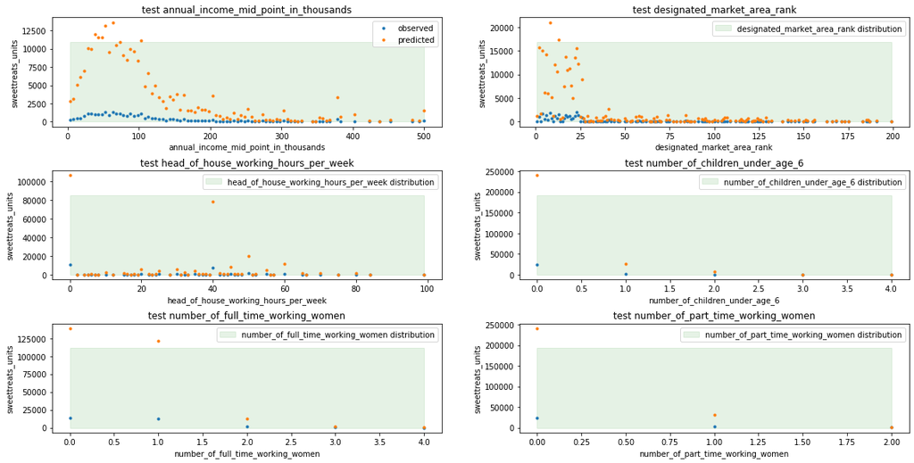

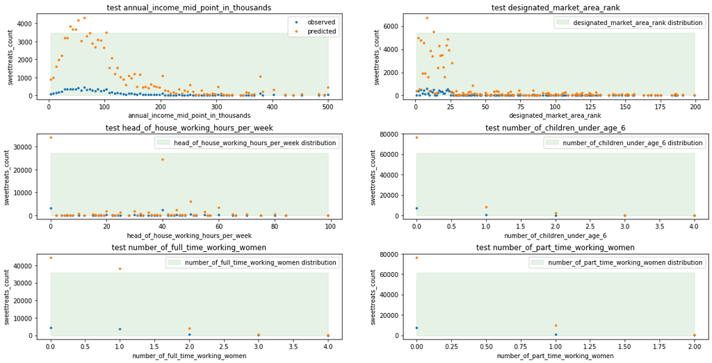

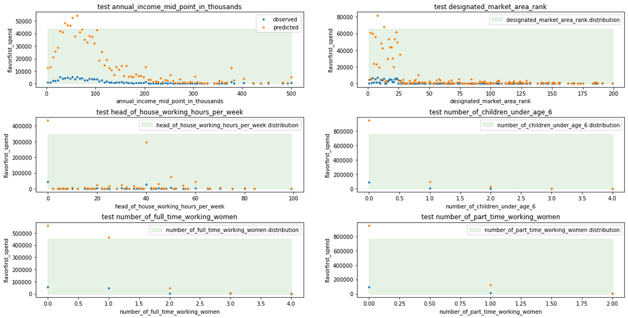

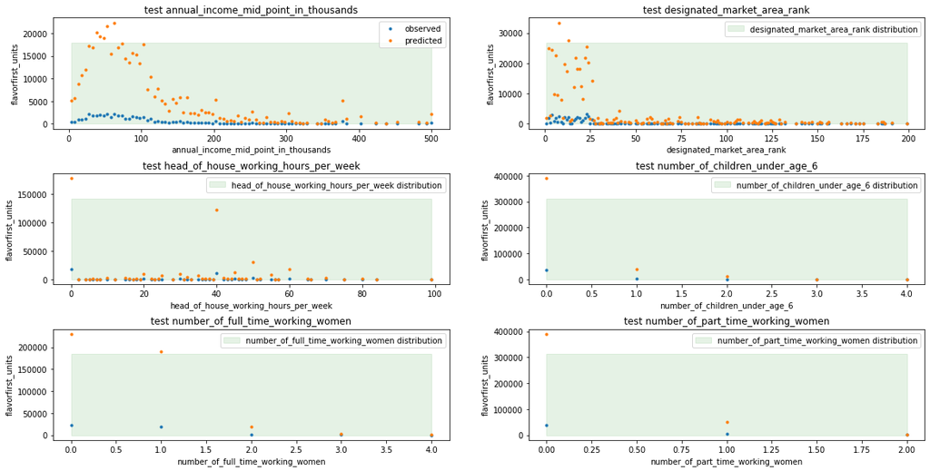

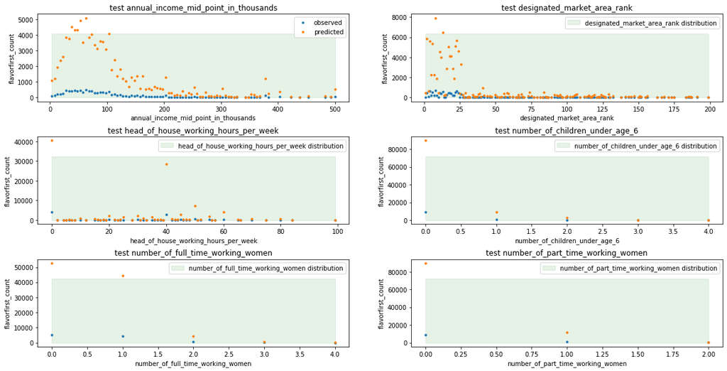

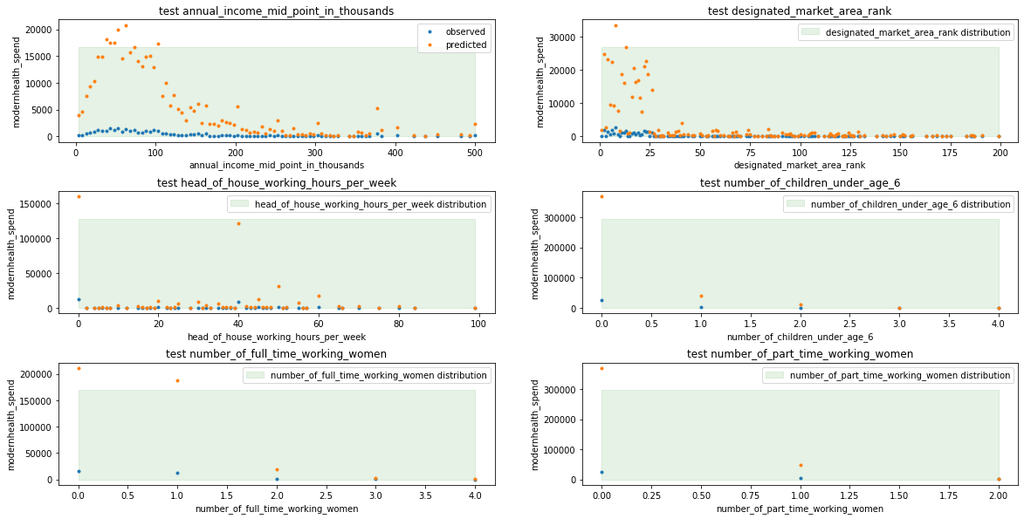

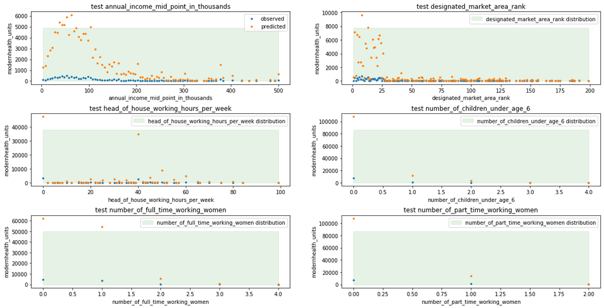

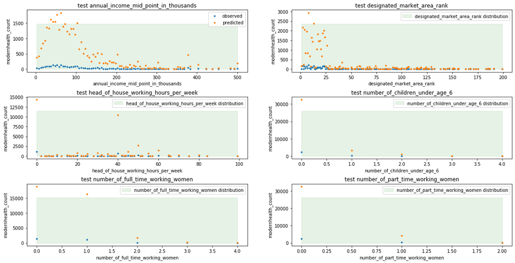

```python
for response, model in model_dict.items():
    fig, ax = plt.subplots(ncols=2, nrows=3, figsize=(16, 8))
    fig.tight_layout()
    fig.subplots_adjust(wspace = 0.2, hspace = 0.4)

    plot_obs_pred(
        df=df_test,
        X = X_test,
        feature="annual_income_mid_point_in_thousands",
        target=response,
        model=model,
        exposure = exposure_var,
        y_label=response,
        ax=ax[0, 0],
    )

    plot_obs_pred(
        df=df_test,
        X = X_test,
        feature="designated_market_area_rank",
        target=response,
        model=model,
        exposure = exposure_var,
        y_label=response,

        ax=ax[0, 1],
        fill_legend=True
    )

    plot_obs_pred(
        df=df_test,
        X = X_test,
        feature="head_of_house_working_hours_per_week",
        target=response,
        model=model,
        exposure = exposure_var,
        y_label=response,

        ax=ax[1, 0],
        fill_legend=True
    )

    plot_obs_pred(
        df=df_test,
        X = X_test,
        feature="number_of_children_under_age_6",
        target=response,
        model=model,
        exposure = exposure_var,
        y_label=response,

        ax=ax[1, 1],
        fill_legend=True
    )

    plot_obs_pred(
        df=df_test,
        X = X_test,
        feature="number_of_full_time_working_women",
        target=response,
        model=model,
        exposure = exposure_var,
        y_label=response,

        ax=ax[2, 0],
        fill_legend=True
    )


    plot_obs_pred(
        df=df_test,
        X = X_test,
        feature="number_of_part_time_working_women",
        target=response,
        model=model,
        exposure = exposure_var,
        y_label=response,

        ax=ax[2, 1],
        fill_legend=True
    )
```

# Step4: Model Diagnose

### 4.1 Determine the modeling power in sorting testing values

- Determine whether the model is able to predict the response in correct sorting order.
- Rank the prediction, superimpose with the actual values to compare.
- both multiply with normalization factor or not with multiply with normalization factor.

```python
#Before multiply prediction with normalization factor
#Meaning predicting using only demographic variables
#The order didn't match well
```

```
Actual number of claims: 27161.0
```

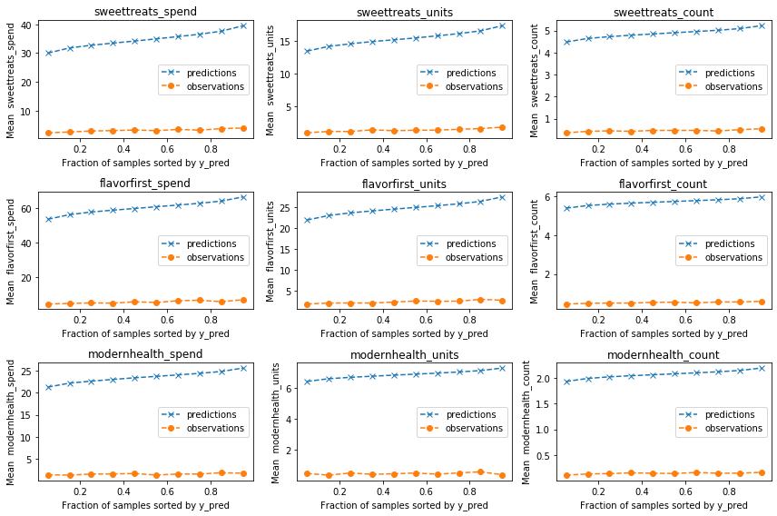

```python
from sklearn.utils import gen_even_slices
def _mean_frequency_by_risk_group(y_true, y_pred, sample_weight=None,
                                  n_bins=100):
    """Compare predictions and observations for bins ordered by y_pred.

    We order the samples by ``y_pred`` and split it in bins.
    In each bin the observed mean is compared with the predicted mean.

    Parameters
    ----------
    y_true: array-like of shape (n_samples,)
        Ground truth (correct) target values.
    y_pred: array-like of shape (n_samples,)
        Estimated target values.
    sample_weight : array-like of shape (n_samples,)
        Sample weights.
    n_bins: int
        Number of bins to use.

    Returns
    -------
    bin_centers: ndarray of shape (n_bins,)
        bin centers
    y_true_bin: ndarray of shape (n_bins,)
        average y_pred for each bin
    y_pred_bin: ndarray of shape (n_bins,)
        average y_pred for each bin
    """
    idx_sort = np.argsort(y_pred)
    bin_centers = np.arange(0, 1, 1/n_bins) + 0.5/n_bins
    y_pred_bin = np.zeros(n_bins)
    y_true_bin = np.zeros(n_bins)

    for n, sl in enumerate(gen_even_slices(len(y_true), n_bins)):
        weights = sample_weight
        y_pred_bin[n] = np.average(
            y_pred[idx_sort][sl], weights=weights
        )
        y_true_bin[n] = np.average(
            y_true[idx_sort][sl],
            weights=weights
        )
    return bin_centers, y_true_bin, y_pred_bin


print(f"Actual number of claims: {df_test['sweettreats_units'].sum()}")

fig, ax = plt.subplots(nrows=3, ncols=3, figsize=(12, 8))
plt.subplots_adjust(wspace=0.3)

# print(ax)

for axi, var, model in zip(ax.ravel(), model_dict.keys(), model_dict.values()):
    y_pred = model.predict(X_test)
    y_true = df_test[var].values/df_test[exposure_var].values
#     exposure = df_test["Exposure"].values
    q, y_true_seg, y_pred_seg = _mean_frequency_by_risk_group(y_true, y_pred, n_bins=10)
#     print(q, y_true_seg, y_pred_seg)

    # Name of the model after the estimator used in the last step of the
    # pipeline.
#     print(f"Predicted number of claims by {model}: "
#           f"{np.sum(y_pred ):.1f}")

    axi.plot(q, y_pred_seg, marker='x', linestyle="--", label="predictions")
    axi.plot(q, y_true_seg, marker='o', linestyle="--", label="observations")
#     axi.set_xlim(0, 1.0)
#     axi.set_ylim(0, 0.5)
    axi.set(
        title=var,
        xlabel='Fraction of samples sorted by y_pred',
        ylabel='Mean  '+var
    )
    axi.legend()
plt.tight_layout()
```

```python
#After multiple prediction with normalization factor
#Meaning predicting using only demographic variables and normalizing factor
#The order almost matched perfectly, proving the normalizing factor is important in predicting
```

```
Actual number of claims: 27161.0
```

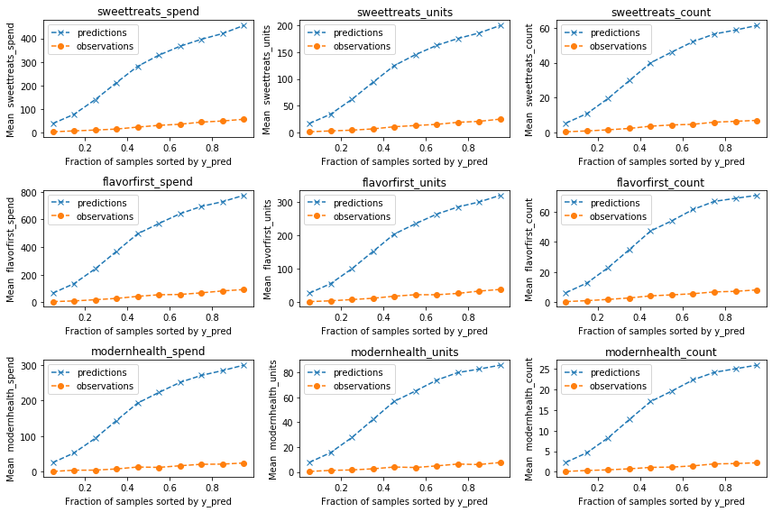

```python
from sklearn.utils import gen_even_slices


def _mean_frequency_by_risk_group(y_true, y_pred, sample_weight=None,
                                  n_bins=100):
    """Compare predictions and observations for bins ordered by y_pred.

    We order the samples by ``y_pred`` and split it in bins.
    In each bin the observed mean is compared with the predicted mean.

    Parameters
    ----------
    y_true: array-like of shape (n_samples,)
        Ground truth (correct) target values.
    y_pred: array-like of shape (n_samples,)
        Estimated target values.
    sample_weight : array-like of shape (n_samples,)
        Sample weights.
    n_bins: int
        Number of bins to use.

    Returns
    -------
    bin_centers: ndarray of shape (n_bins,)
        bin centers
    y_true_bin: ndarray of shape (n_bins,)
        average y_pred for each bin
    y_pred_bin: ndarray of shape (n_bins,)
        average y_pred for each bin
    """
    idx_sort = np.argsort(y_pred)
    bin_centers = np.arange(0, 1, 1/n_bins) + 0.5/n_bins
    y_pred_bin = np.zeros(n_bins)
    y_true_bin = np.zeros(n_bins)

    for n, sl in enumerate(gen_even_slices(len(y_true), n_bins)):
        weights = sample_weight
        y_pred_bin[n] = np.average(
            y_pred[idx_sort][sl], weights=weights
        )
        y_true_bin[n] = np.average(
            y_true[idx_sort][sl],
            weights=weights
        )
    return bin_centers, y_true_bin, y_pred_bin


print(f"Actual number of claims: {df_test['sweettreats_units'].sum()}")

fig, ax = plt.subplots(nrows=3, ncols=3, figsize=(12, 8))
plt.subplots_adjust(wspace=0.3)

# print(ax)

for axi, var, model in zip(ax.ravel(), model_dict.keys(), model_dict.values()):
    y_pred = model.predict(X_test)*df_test[exposure_var].values
    y_true = df_test[var].values
#     exposure = df_test["Exposure"].values
    q, y_true_seg, y_pred_seg = _mean_frequency_by_risk_group(y_true, y_pred, n_bins=10)
#     print(q, y_true_seg, y_pred_seg)

    # Name of the model after the estimator used in the last step of the
    # pipeline.
#     print(f"Predicted number of claims by {model}: "
#           f"{np.sum(y_pred ):.1f}")

    axi.plot(q, y_pred_seg, marker='x', linestyle="--", label="predictions")
    axi.plot(q, y_true_seg, marker='o', linestyle="--", label="observations")
#     axi.set_xlim(0, 1.0)
#     axi.set_ylim(0, 0.5)
    axi.set(
        title=var,
        xlabel='Fraction of samples sorted by y_pred',
        ylabel='Mean  '+var
    )
    axi.legend()
plt.tight_layout()
```